# Peer Assessment I

First, let us load the data and necessary packages:

```r
load("ames_train.Rdata")
library(MASS)
library(dplyr)
library(ggplot2)
library(BAS)
```

# 1

Make a labeled histogram (with 30 bins) of the ages of the houses in the data set, and describe the distribution.

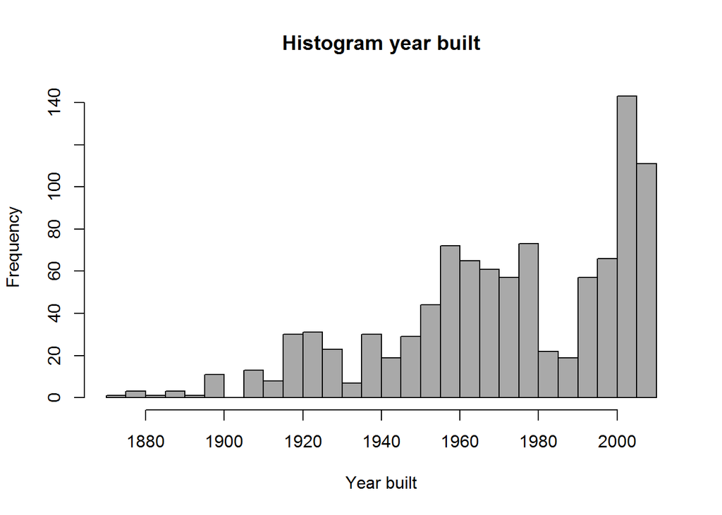

```r
hist(ames_train$Year.Built, main = "Histogram year built", col = "darkgrey", xlab = "Year built", breaks = 30)
```

The diagram shows a left skewed distribution. The distribution is bimodal, caused by the pretty big dip in the 1980’s. Each bar represents five years of aggregated data, that’s the detail level of the distribution. Overall there’s a steady increase in number of houses built as the years progress.

# 2

The mantra in real estate is “Location, Location, Location!” Make a graphical display that relates a home price to its neighborhood in Ames, Iowa. Which summary statistics are most appropriate to use for determining the most expensive, least expensive, and most heterogeneous (having the most variation in housing price) neighborhoods? Report which neighborhoods these are based on the summary statistics of your choice. Report the value of your chosen summary statistics for these neighborhoods.

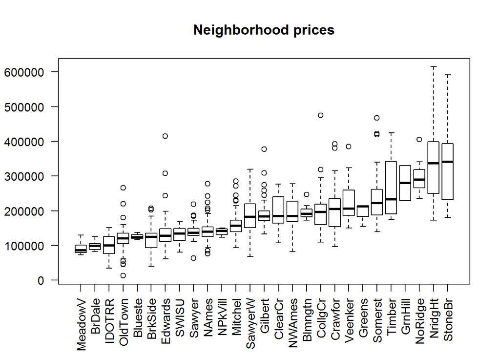

```r
# Extract and calculate price data.
temp1 <- aggregate(list(price = ames_train$price), by=list(Neighborhood=ames_train$Neighborhood), FUN=median)
temp1 <- temp1[with(temp1, order(price)), ]
temp3 <- ames_train[, c("Neighborhood", "price")]
temp3$Neighborhood <- factor(temp3$Neighborhood, order=TRUE, levels=temp1$Neighborhood)
# Plot diagram ordered from lowest to highets median price.
options(scipen=10)
boxplot(price ~ Neighborhood, data = temp3, las = 2, main = "Neighborhood prices")
```

```r
# Print relvant summary.
min(ames_train[which(ames_train$Neighborhood == 'Blueste'), c("price")])
```

```
## [1] 116500
```

```r
max(ames_train[which(ames_train$Neighborhood == 'Blueste'), c("price")])
```

```
## [1] 137000
```

```r
min(ames_train[which(ames_train$Neighborhood == 'NridgHt'), c("price")])
```

```
## [1] 173000
```

```r
max(ames_train[which(ames_train$Neighborhood == 'NridgHt'), c("price")])
```

```
## [1] 615000
```

```r
min(temp1$price)
```

```
## [1] 85750
```

```r
max(temp1$price)
```

```
## [1] 340691.5
```

Median and interquartile range (IQR) are good summary statistics to use for least/most expensive and spread of housing price. The reason is that they are stable statistics that are not affected by extreme values (which mean and standard deviation are).

A boxplot is a good choice for displaying these statistics. The boxplot above displays median value (the horizontal black bar), first and third quartile (the box itself), smallest and largest non-outliers (endpoints of the dashed lines), as well as outliers (circles beyond the endpoints of the dashed lines).

Most expensive/least expensive area is determined by the median of price, the higher the median the more expensive neighborhood, and vice versa. The least expensive area is MeadowV, with median price 85750. The most expensive area is StoneBr, with median price 340691.5.

# 3

Which variable has the largest number of missing values? Explain why it makes sense that there are so many missing values for this variable.

```r
head(sort(sapply(ames_train, function(x) sum(is.na(x))), decreasing = TRUE), n = 1)
```

```
## Pool.QC
##     997
```

Pool quality has the largest number of missing values. The reason for this is that most houses don’t have a pool, which is indicated by NA according to the variable definition.

# 4

We want to predict the natural log of the home prices. Candidate explanatory variables are lot size in square feet (Lot.Area), slope of property (Land.Slope), original construction date (Year.Built), remodel date (Year.Remod.Add), and the number of bedrooms above grade (Bedroom.AbvGr). Pick a model selection or model averaging method covered in the Specialization, and describe how this method works. Then, use this method to find the best multiple regression model for predicting the natural log of the home prices.

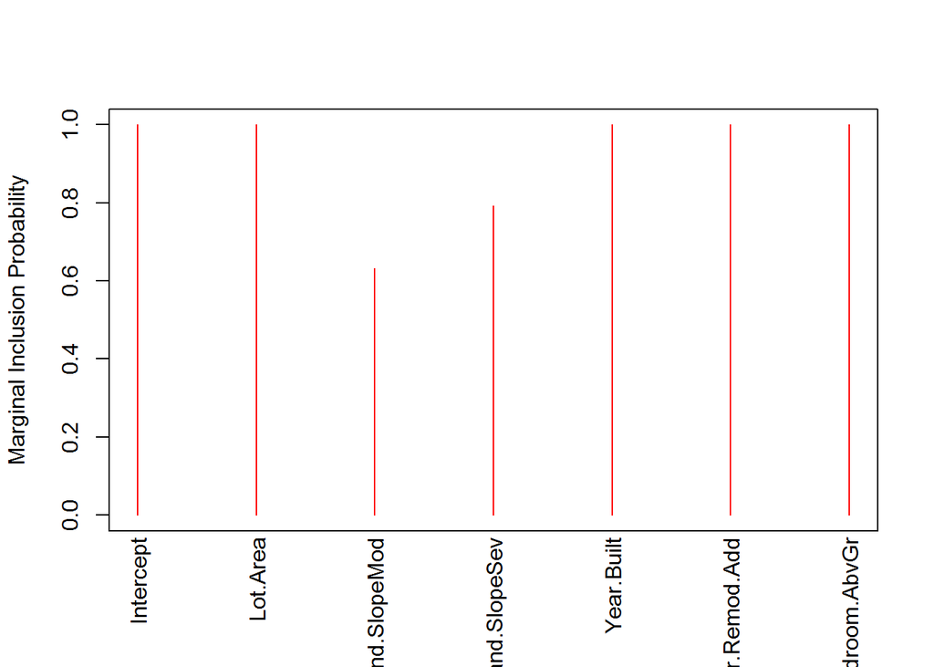

```r
bma_model1 <- bas.lm(log(price) ~ Lot.Area + Land.Slope + Year.Built + Year.Remod.Add + Bedroom.AbvGr, data = ames_train, prior = "BIC", modelprior = uniform())
plot(bma_model1, which = 4, ask=FALSE, caption="", sub.caption="")
```

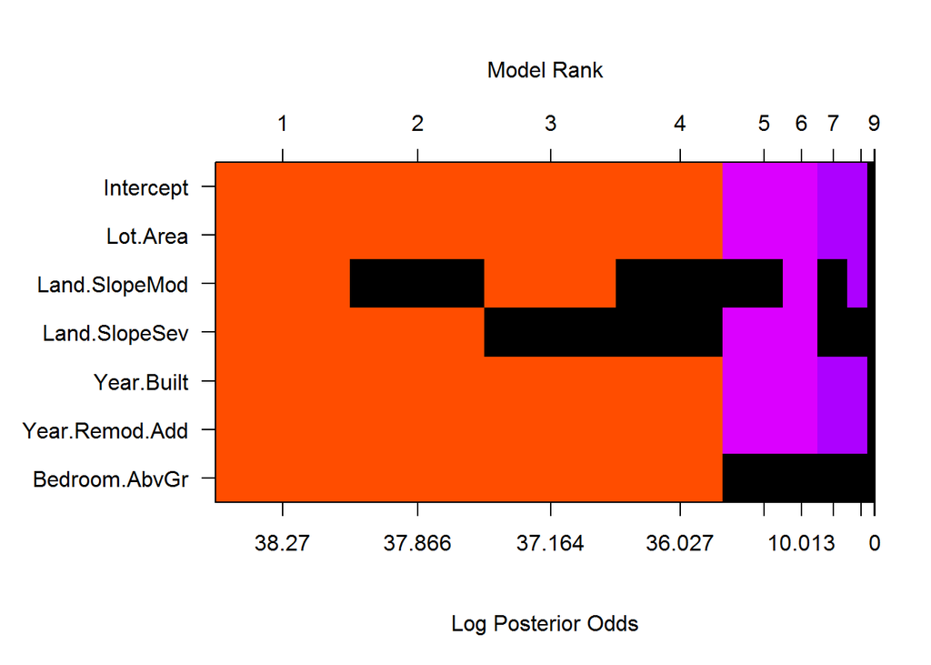

```r
image(bma_model1, top.models = 10, rotate = F)
```

Bayesian Model Averaging (BMA) will be used as the base model to find the model for estimation. This is because BMA uses multiple models and represents the full posterior uncertainty for the data.

The BMA model is created with Bayesian Information Criterion (BIC) used as metric for model selection. BIC is based on model fit, while simultaneously penalizing the number of parameters in proportion to the sample size, so it is a good metric for finding a model with not too many parameters. Model prior is set as uniform, meaning all models have equal prior probability.

The first plot shows the marginal posterior inclusion probabilities for each of the variables. It looks like all variables are good predicators and are likely to be included in the final model. The “worst” predicator is `Land.Slope` with a 60% chance of being included in the final model.

The second plot shows model ranks and the top ranked model is the one including all variables, so that is the best model for predicting log(price).

# 5

Which home has the largest squared residual in the previous analysis (Question 4)? Looking at all the variables in the data set, can you explain why this home stands out from the rest (what factors contribute to the high squared residual and why are those factors relevant)?

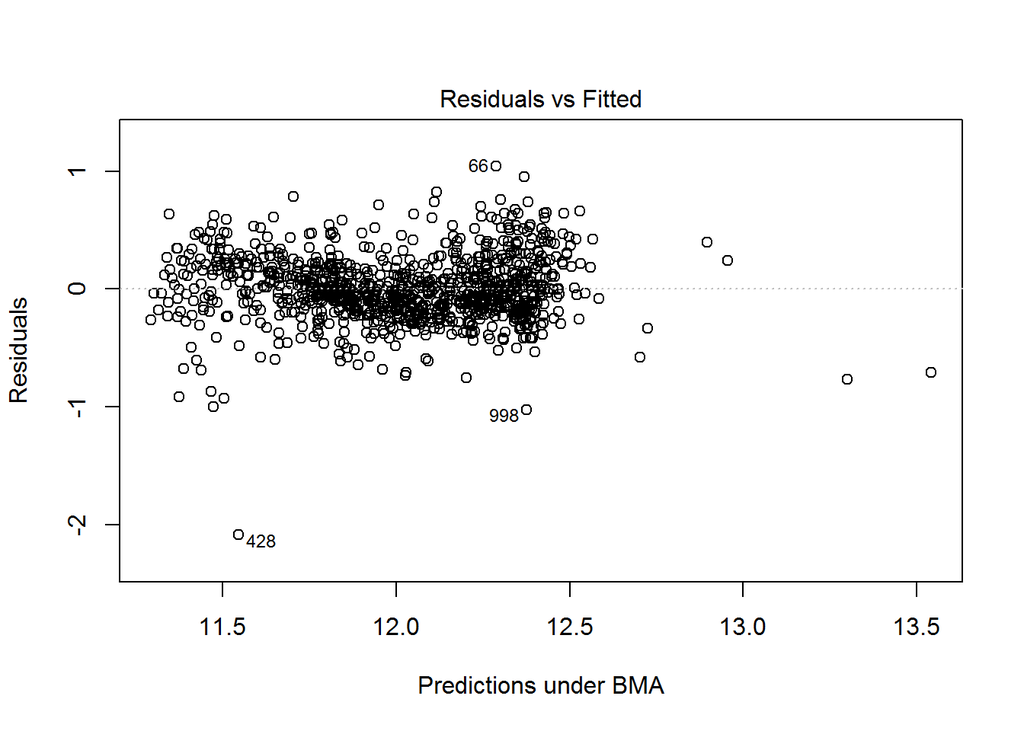

```r
plot(bma_model1, which = 1, add.smooth = FALSE, sub.caption = "")
```

```r
ames_train[66,c("price", "Lot.Area", "Land.Slope", "Year.Built", "Year.Remod.Add", "Bedroom.AbvGr")]
```

```
## Source: local data frame [1 x 6]
##
##    price Lot.Area Land.Slope Year.Built Year.Remod.Add Bedroom.AbvGr
##    <int>    <int>     <fctr>      <int>          <int>         <int>
## 1 615000    12720        Mod       2003           2003             1
```

```r
summary(ames_train$Lot.Area)
```

```
##    Min. 1st Qu.  Median    Mean 3rd Qu.    Max.
##    1470    7314    9317   10350   11650  215200
```

```r
summary(ames_train$price)
```

```
##    Min. 1st Qu.  Median    Mean 3rd Qu.    Max.
##   12790  129800  159500  181200  213000  615000
```

`Lot.Area` is larger than the third quartile but way smaller than max, so it doesn’t stand out either.

# 6

Use the same model selection method you chose in Question 4 to again find the best multiple regression model to predict the natural log of home prices, but this time **replacing Lot.Area with log(Lot.Area)**. Do you arrive at a model including the same set of predictors?

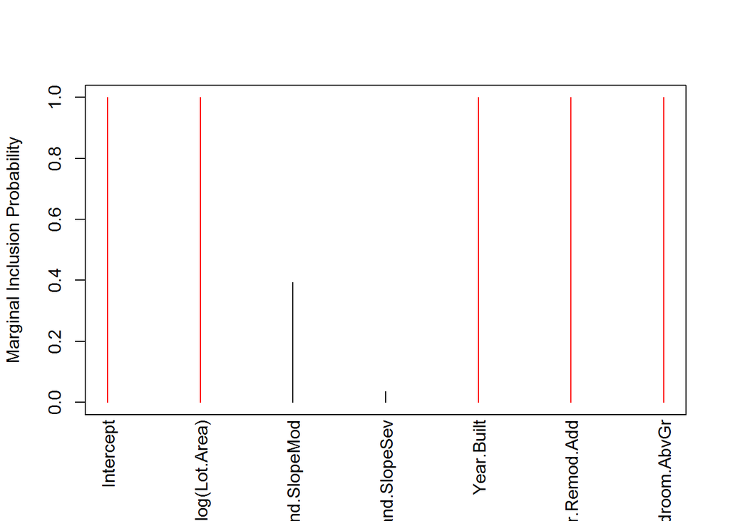

```r
bma_model2 <- bas.lm(log(price) ~ log(Lot.Area) + Land.Slope + Year.Built + Year.Remod.Add + Bedroom.AbvGr, data = ames_train, prior = "BIC", modelprior = uniform())
plot(bma_model2, which = 4, ask=FALSE, caption="", sub.caption="")
```

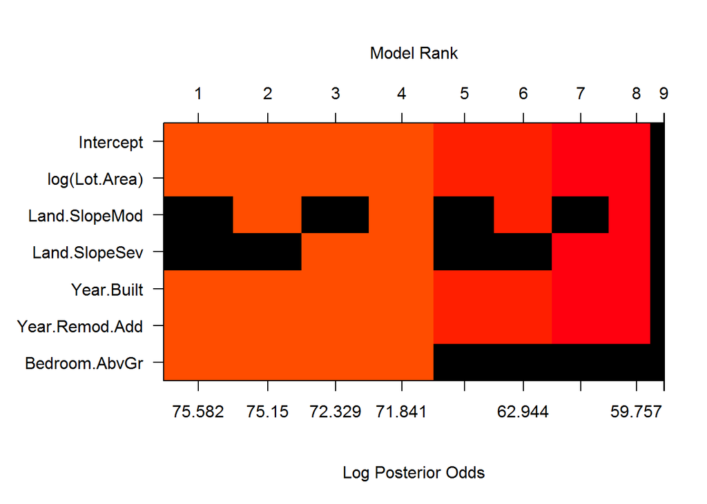

```r
image(bma_model2, top.models = 10, rotate = F)
```

The first plot shows that `Land.Slope` drops in likelihood do be included in the final model. And the model ranks shows that it is indeed dropped from the top ranked model. The top ranked model now consists of four variables (`log(Lot.Area)`, `Year.Built`, `Year.Remod.Add`, `Bedroom.AbvGr`), so it’s a different model than before.

# 7

Do you think it is better to log transform Lot.Area, in terms of assumptions for linear regression? Make graphs of the predicted values of log home price versus the true values of log home price for the regression models selected for Lot.Area and log(Lot.Area). Referencing these two plots, provide a written support that includes a quantitative justification for your answer in the first part of question 7.

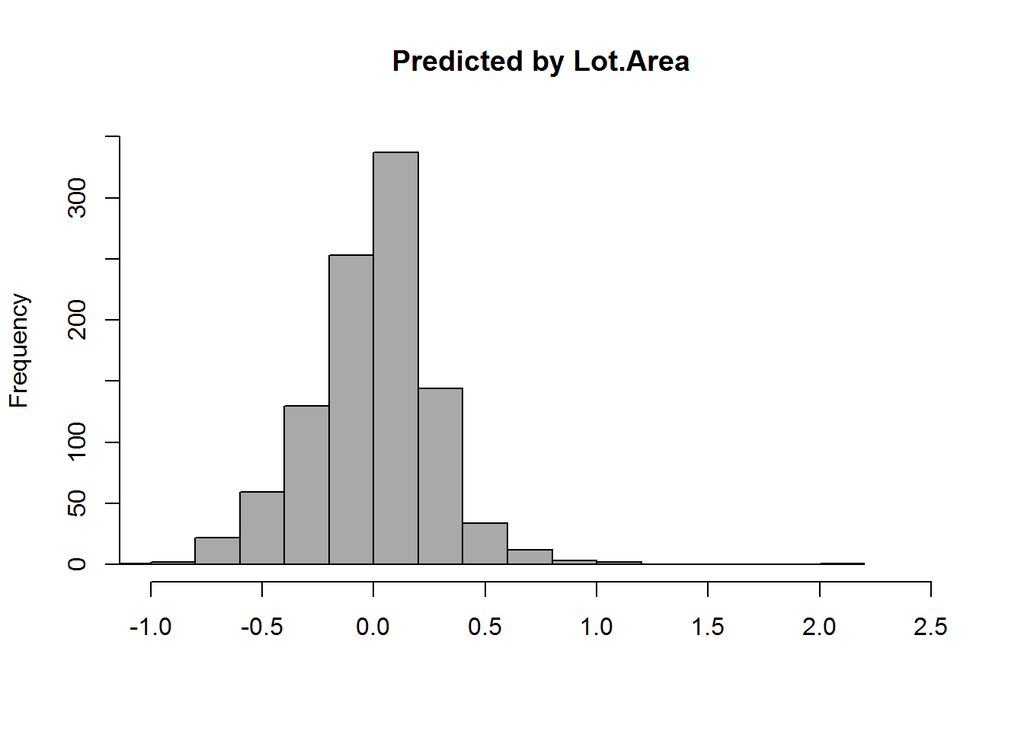

```r
log_price <- log(ames_train$price)
ames_train_predict1 <- predict(bma_model1, estimator="BMA")
ames_train_predict2 <- predict(bma_model2, estimator="BMA")
hist(ames_train_predict1$fit - log_price, xlim = c(-1.0, 2.5), ylim = c(0, 350), main = "Predicted by Lot.Area", xlab = "", col = "darkgrey", breaks = 20)
```

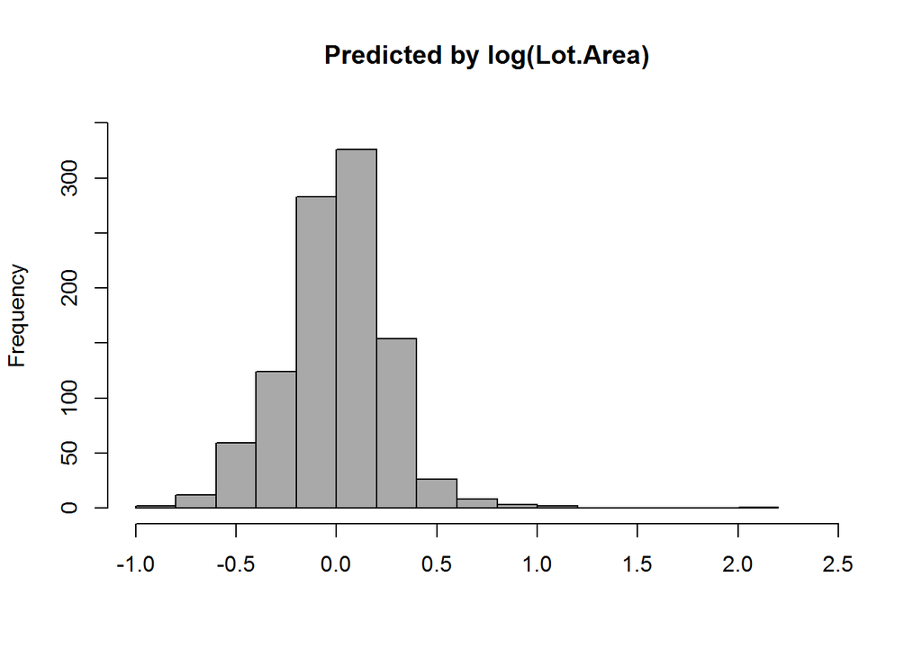

```r
hist(ames_train_predict2$fit - log_price, xlim = c(-1.0, 2.5), ylim = c(0, 350), main = "Predicted by log(Lot.Area)", xlab = "", col = "darkgrey", breaks = 20)
```

I would think that the log transformation is better. The lot area distribution is very right skewed and much of the data cluster near zero and all observations are positive, so it’s a textbook example where log transformation can be used to make the relationship between the two variables more linear. (This is not shown here, but can be displayed by plotting histogram of lot area and log transformed lot area.)

Subtracting log transformed price from the respective predicted price from the two models and plotting histogram would show that the one that is mostly centered around zero is the best predicator. If a model was perfect, predicted price minus observed price would be zero for each prediction. Looking at the plots it’s very close, but the second plot with log transformed is *slightly* more centered around zero. The second model with log transformed is therefore probably better.